# R Notebook

# Load the data and process the text

```r
library("wordcloud")
library("tidytext")
library("ggplot2")
library("rvest")
library("tibble")
library("qdap")
library("sentimentr")
library("gplots")
library("dplyr")
library("tm")
library("syuzhet")
library("factoextra")
library("beeswarm")
library("scales")
library("RColorBrewer")
library("RANN")
library("tm")
library("topicmodels")
library("reshape2")


folder.path="../data/InauguralSpeeches/"
speeches=list.files(path = folder.path, pattern = "*.txt")
prez.out=substr(speeches, 6, nchar(speeches)-4)

length.speeches=rep(NA, length(speeches))
docs<-Corpus(DirSource(folder.path,encoding = "UTF-8"))

docs<-tm_map(docs, stripWhitespace)
docs<-tm_map(docs, content_transformer(tolower))
docs<-tm_map(docs, removeNumbers)
docs<-tm_map(docs, removeWords, stopwords("english"))
docs<-tm_map(docs, removeWords, c("can","will","shall","nation","day","now","may","among","would","america","must","with","without","might","let","american","upon"))
docs<-tm_map(docs, removeWords, character(0))
docs<-tm_map(docs, removePunctuation)
docs <- tm_map(docs,stemDocument)

D<-as.data.frame(docs)
D$docs<-paste(prez.out)


dtm <- DocumentTermMatrix(docs)
dtmss <- removeSparseTerms(dtm, 0.15)

rownames(dtm) <- paste(prez.out)
rowTotals <- apply(dtm , 1, sum) #Find the sum of words in each Document
dtm  <- dtm[rowTotals> 0, ]
dtm.mat<-as.matrix(dtm)
dtm.df<-as.data.frame(dtm.mat)
dtm.df<-data.frame(File=dtm$dimnames$Docs,dtm.df)

library("xlsx")
filename<-"../data/InaugurationInfo.xlsx"
presid.info<-read.xlsx(file = filename,1,encoding="UTF-8",header=T)

presid.term<-merge(presid.info,dtm.df,by="File",all=T)

presid.term<-presid.term[order(presid.term$Time),]

presid.term$File <- factor(presid.term$File, levels=presid.term$File, ordered=TRUE)

dtm.df<-presid.term[,-c(2,3,4,5,6)]
dtm.mat<-as.matrix(dtm.df)
```

Gather the 58 speeches of the US president and process the text to the form in which we can analyze.

```r
print(R.version)
```

```
##                _
## platform       x86_64-w64-mingw32
## arch           x86_64
## os             mingw32
## system         x86_64, mingw32
## status
## major          3
## minor          3.2
## year           2016
## month          10
## day            31
## svn rev        71607
## language       R
## version.string R version 3.3.2 (2016-10-31)
## nickname       Sincere Pumpkin Patch
```

# Words Frenquency Analysis

We are interested in those words that are frequently used in the inaugspeeches of the US presidents.

After delete all the uncorrelated words in the text, we graph the high frequently used words as follow.

```r
h.freq<-findFreqTerms(dtm,lowfreq = 160)
#length(h.freq)
print(h.freq)
```

```
##  [1] "citizen"   "constitut" "countri"   "duti"      "everi"
##  [6] "free"      "freedom"   "govern"    "great"     "hope"
## [11] "interest"  "law"       "make"      "nation"    "new"
## [16] "one"       "peac"      "peopl"     "power"     "public"
## [21] "right"     "secur"     "state"     "time"      "union"
## [26] "unit"      "war"       "world"     "year"
```

These are words shown up more than 160 times in the speeches.

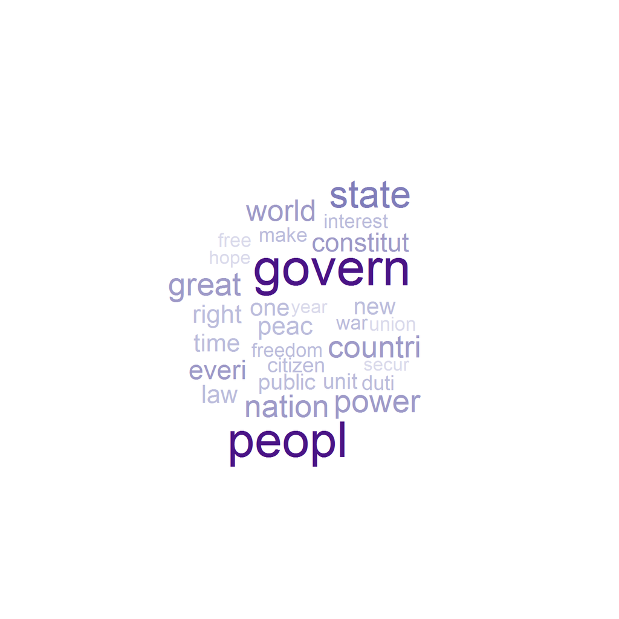

```r
freq<-sort(colSums(as.matrix(dtm)),decreasing = T)
wordcloud(names(freq),freq,max.words = length(h.freq),colors=brewer.pal(7,"Purples"),rot.per = F)
```

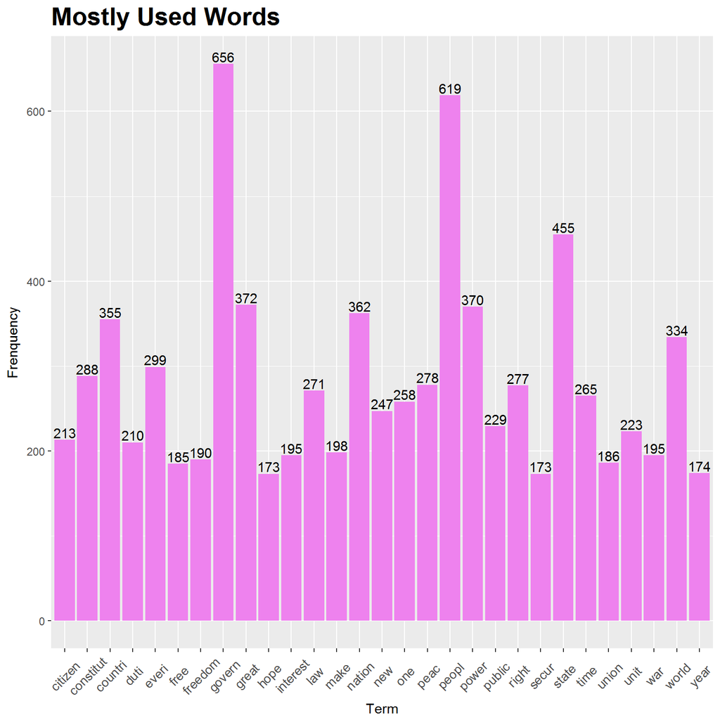

```r
# Frequency for the high ~ words
obj<-freq[freq >= 160]
h.f<-data.frame(term=names(obj),freq=obj)

ggplot(h.f, aes(x=term,y=freq)) +
             geom_bar(stat="identity",fill="Violet")+
             labs(title="Mostly Used Words",x="Term",y="Frenquency")+
             theme(axis.text.x  = element_text(angle=45, size=10,vjust=0.5),
                   plot.title = element_text(colour = "black", face = "bold",size = 20,vjust = 1))+
             geom_text(aes(label=freq), vjust=-0.2)
```

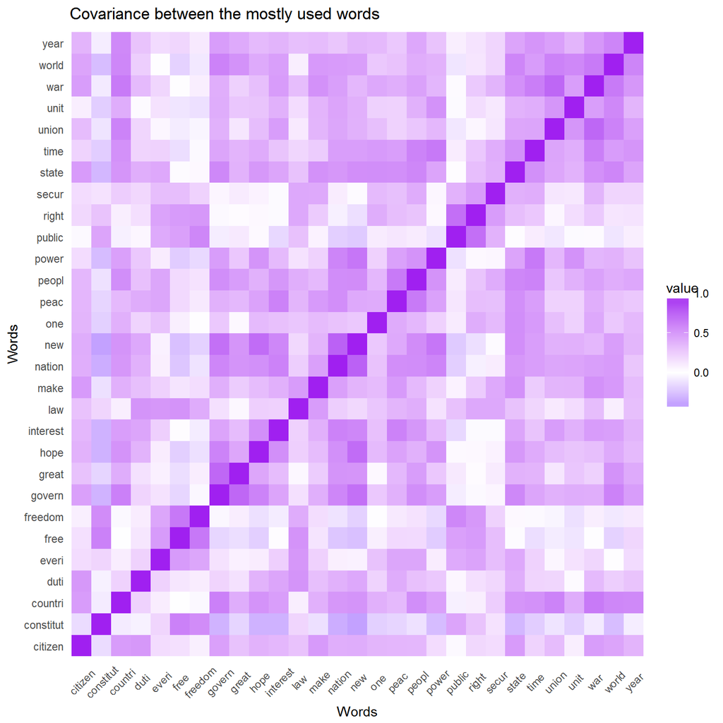

```r
m1<-dtm.mat[,h.freq]
cn<-colnames(m1)
rn<-dtm.mat[,"File"]
dtm.freq.mat<-matrix(as.numeric(m1),byrow=T,nrow=58)
colnames(dtm.freq.mat)<-cn
rownames(dtm.freq.mat)<-rn

corr.freq<-cor(dtm.freq.mat)
coln<-colnames(corr.freq)
corr.freq<-melt(corr.freq)
ggplot(data = corr.freq) +
    geom_tile(aes(x = Var1, y = Var2, fill = value)) +
    theme_classic() +
    theme(axis.ticks = element_blank(),
          axis.line = element_blank(),
          axis.text.x  = element_text(angle=45, vjust=0.5)) +
    labs(title="Covariance between the mostly used words ",x="Words",y="Words")+
    scale_x_discrete(labels = coln) +
    scale_y_discrete(labels = coln) +
    scale_fill_gradient2('value',
                         low = "blue", mid = "white", high = "purple")
```

This is the correlation heatmap of the most useds words. As color goes deeper, the correlation between the two words are more closely.

As we can see “Year,World,War”,“Great,Govern,Hope”,“Power,People,Peace” are highly correlated.

We plot the words clustering as follows:

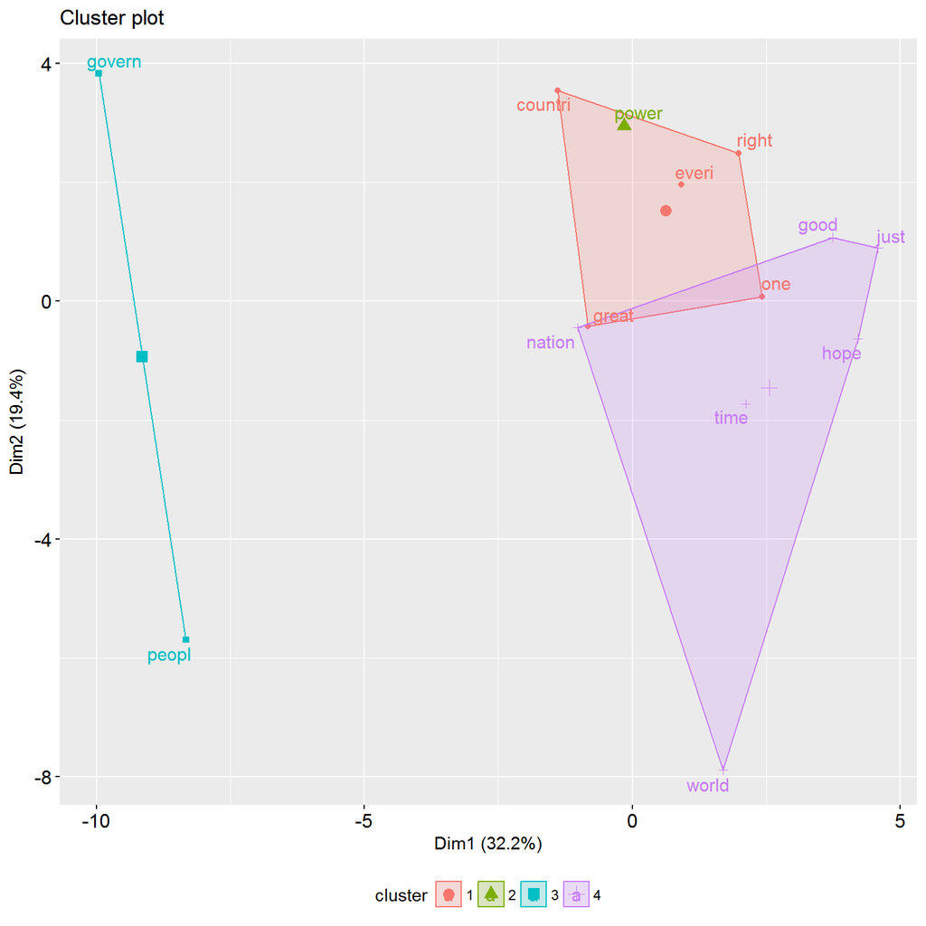

```r
library(factoextra)
set.seed(1994)
km.res=kmeans(t(dtmss), iter.max=200,4)
fviz_cluster(km.res,
             stand=T, repel= TRUE,
             data = t(dtmss),
             show.clust.cent=TRUE)
```

As we can see “People, Govern”, “world,nation,hope”,“great,country,right” are clustered in classes.

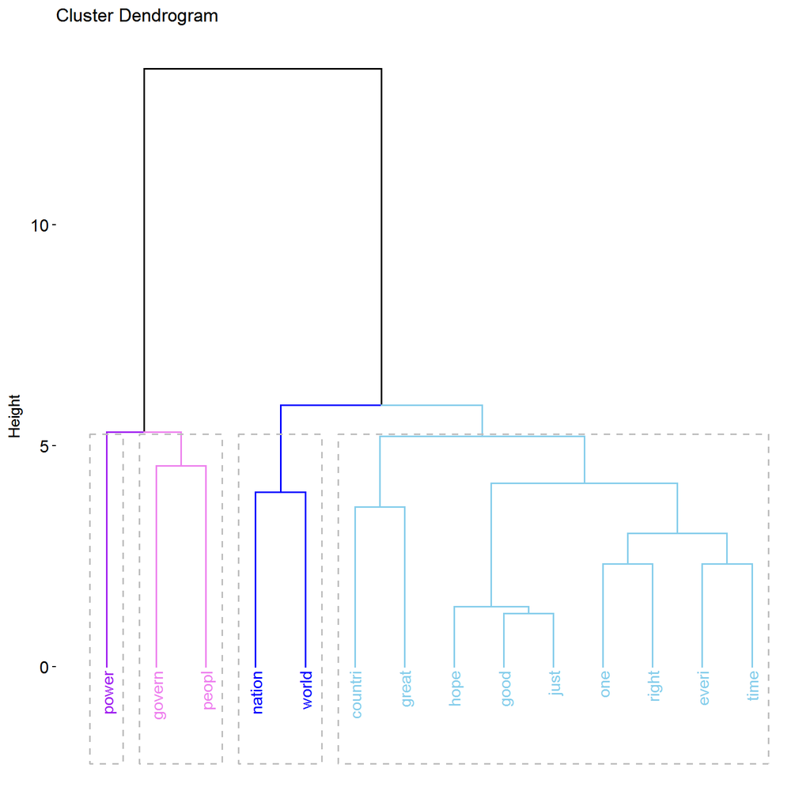

```r
# Compute hierarchical clustering
d <- dist(t(dtmss), method = "euclidean")
res <- hcut(d, k = 4, stand = TRUE)
fviz_dend(res, rect = TRUE, cex = 0.8,
          k_colors = c("purple","violet","blue","skyblue"))
```

We plot the frequency of highly used words according to the time trend:

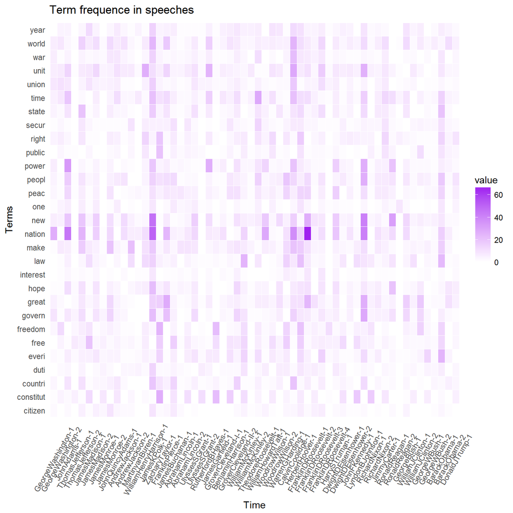

```r
# high frequency words apperence in each docs
coln<-colnames(dtm.freq.mat)
rown<-rownames(dtm.freq.mat)
ggplot(data = melt(dtm.freq.mat)) +
    geom_tile(aes(x = Var1, y = Var2, fill = value),color = "white") +
    labs(title="Term frequence in speeches", x="Time",y="Terms")+
    theme_classic() +
    theme(axis.ticks = element_blank(),
          axis.line = element_blank(),
          axis.text.x  = element_text(angle=60, vjust=0.5) ) +
    scale_fill_gradient(low = "white",high = "purple")+
    scale_x_discrete(labels =rown) +
    scale_y_discrete(labels =coln)
```

As we can see, “nation” is the word that appears most in some period. And this can be relate to the historical background like wars

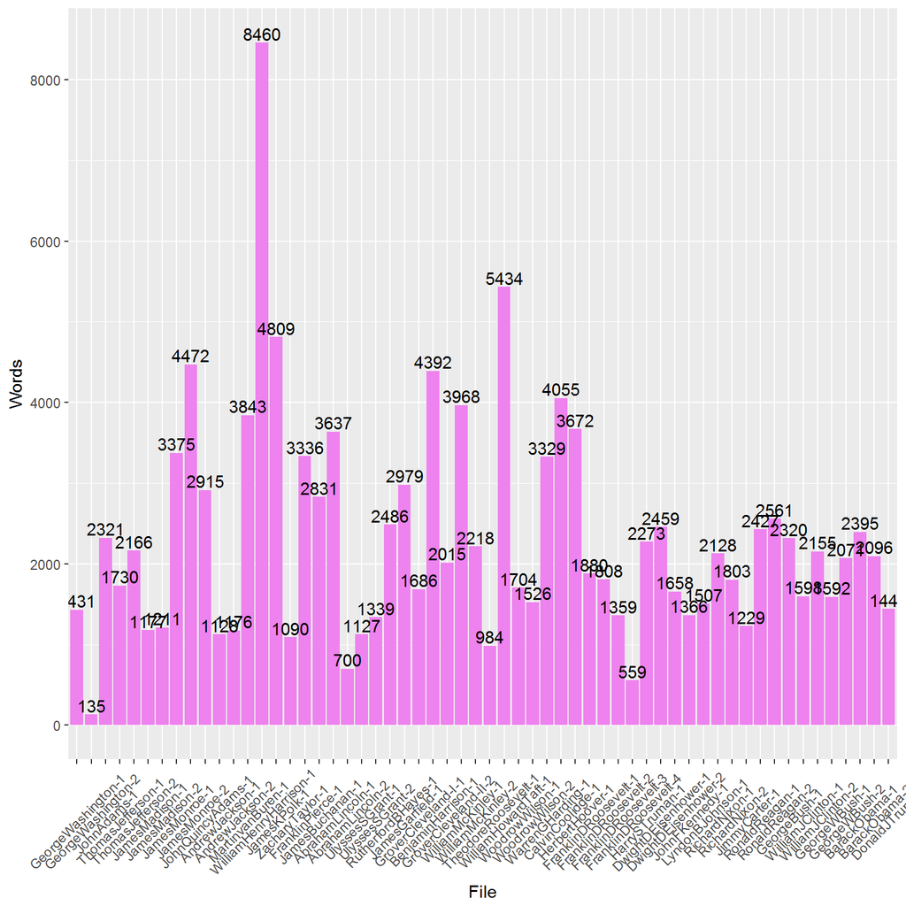

```r
# Words counting
ggplot(presid.term, aes(x=File,y=Words)) +
             geom_bar(stat="identity",fill="violet")+

             theme(axis.text.x  = element_text(angle=45, vjust=0.5))+
             geom_text(aes(label=Words), vjust=-0.2)
```

```r
library(gridExtra)
```

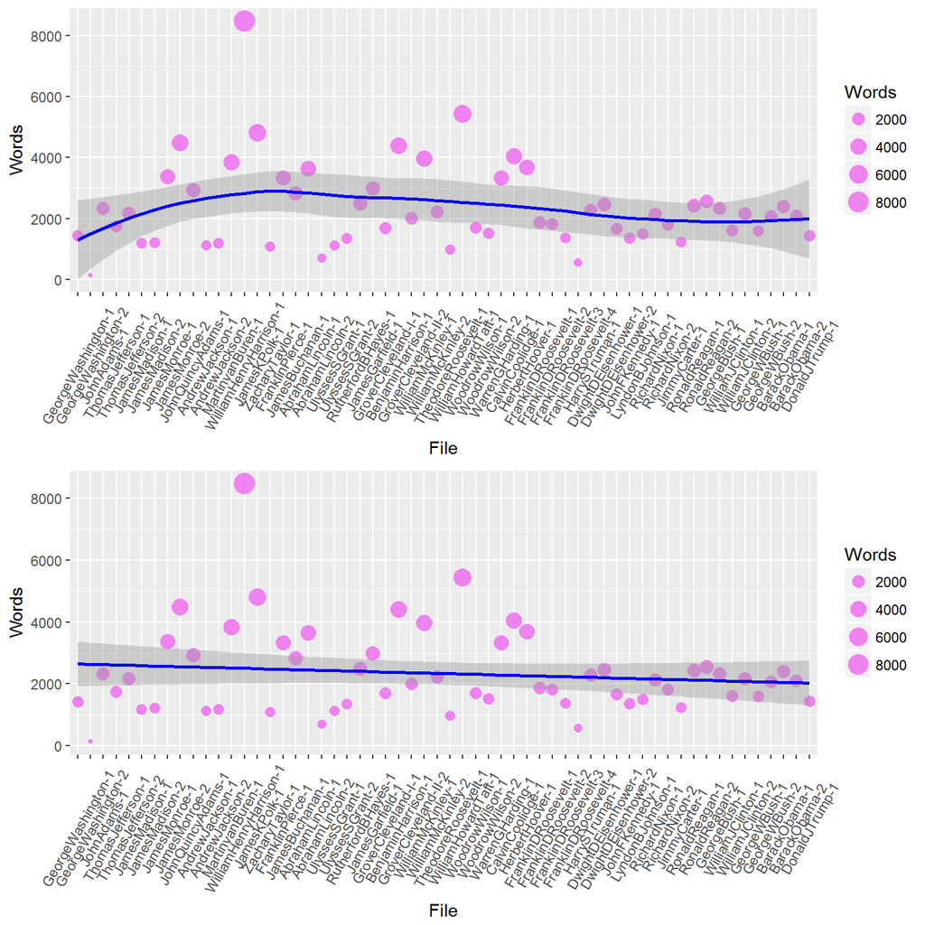

```r
a<-ggplot(presid.term,aes(x=File,y=Words,group=1))+
          geom_point(aes(size=Words) ,col="violet") +
          geom_smooth(formula=y~x,method="loess",col="blue")+
          theme(axis.text.x  = element_text(angle=60, vjust=0.5))

b<-ggplot(presid.term,aes(x=File,y=Words,group=1))+
          geom_point(aes(size=Words) ,col="violet") +
          geom_smooth(formula=y~x,method="lm",col="blue")+
          theme(axis.text.x  = element_text(angle=60, vjust=0.5))
grid.arrange(a,b,nrow=2)
```

It is easy to notice the trend that the words used in the speeches are decreasing as time went by.

# Topic Analysis

Run LDA

```r
#Set parameters for Gibbs sampling
burnin <- 4000
iter <- 1000
thin <- 500
seed <-list(2003,5,63,100001,765)
nstart <- 5
best <- TRUE

#Number of topics
k <- 10

#Run LDA using Gibbs sampling
  ldaOut <-LDA(dtm, k, method="Gibbs", control=list(nstart=nstart,
                                                seed = seed, best=best,
                                                burnin = burnin, iter = iter,
                                                thin=thin))
#write out results
#docs to topics
ldaOut.topics <- as.matrix(topics(ldaOut))
table(c(1:k, ldaOut.topics))
```

```
##
##  1  2  3  4  5  6  7  8  9 10
##  3  6  6 14 15  1  5  8  6  4
```

```r
write.csv(ldaOut.topics,file=paste("../output/LDAGibbs",k,"DocsToTopics.csv"))

#top 6 terms in each topic
ldaOut.terms <- as.matrix(terms(ldaOut,20))
write.csv(ldaOut.terms,file=paste("../output/LDAGibbs",k,"TopicsToTerms.csv"))

#probabilities associated with each topic assignment
topicProbabilities <- as.data.frame(ldaOut@gamma)
write.csv(topicProbabilities,file=paste("../output/LDAGibbs",k,"TopicProbabilities.csv"))

topic.p.mat<-as.matrix(topicProbabilities)
```

```r
terms.beta=ldaOut@beta
terms.beta=scale(terms.beta)
topics.terms=NULL
for(i in 1:k){
  topics.terms=rbind(topics.terms, ldaOut@terms[order(terms.beta[i,], decreasing = TRUE)[1:7]])
}
topics.terms
```

```
##       [,1]          [,2]         [,3]       [,4]       [,5]
##  [1,] "grant"       "oper"       "instanc"  "former"   "actual"
##  [2,] "amend"       "south"      "suggest"  "court"    "negro"
##  [3,] "sea"         "proceed"    "commenc"  "contest"  "naval"
##  [4,] "sentiment"   "acknowledg" "cultiv"   "function" "various"
##  [5,] "challeng"    "born"       "strive"   "hour"     "defin"
##  [6,] "citizenship" "manifest"   "coven"    "rejoic"   "laid"
##  [7,] "object"      "republican" "prescrib" "separ"    "agit"
##  [8,] "answer"      "journey"    "job"      "child"    "yes"
##  [9,] "econom"      "activ"      "stabil"   "concept"  "expans"
## [10,] "energi"      "counsel"    "day"      "process"  "fals"
##       [,6]         [,7]
##  [1,] "legislatur" "scheme"
##  [2,] "canal"      "elector"
##  [3,] "facil"      "resort"
##  [4,] "impress"    "calcul"
##  [5,] "structur"   "cultur"
##  [6,] "elsewher"   "farmer"
##  [7,] "amount"     "compromis"
##  [8,] "compass"    "conquer"
##  [9,] "recoveri"   "grown"
## [10,] "lost"       "alter"
```

```r
ldaOut.terms
```

```
##       Topic 1    Topic 2     Topic 3     Topic 4         Topic 5
##  [1,] "power"    "law"       "great"     "countri"       "world"
##  [2,] "peopl"    "congress"  "war"       "public"        "new"
##  [3,] "execut"   "make"      "state"     "duti"          "freedom"
##  [4,] "citizen"  "busi"      "unit"      "everi"         "peopl"
##  [5,] "parti"    "govern"    "year"      "interest"      "peac"
##  [6,] "govern"   "polici"    "made"      "principl"      "hope"
##  [7,] "patriot"  "offic"     "forc"      "nation"        "make"
##  [8,] "well"     "secur"     "less"      "just"          "live"
##  [9,] "charact"  "import"    "maintain"  "best"          "year"
## [10,] "act"      "condit"    "place"     "foreign"       "god"
## [11,] "spirit"   "proper"    "commerc"   "confid"        "need"
## [12,] "great"    "question"  "sinc"      "honor"         "great"
## [13,] "howev"    "enforc"    "support"   "institut"      "faith"
## [14,] "one"      "respect"   "alway"     "prosper"       "free"
```

[output cut: 27 more lines]

There are some connections within the words in one topic.

```r
library(networkD3)

networkData<-as.data.frame(ldaOut.terms)


simpleNetwork(networkData,Source=networkData$Topic1,Target = networkData$Topic1,fontSize=15)
```

[interactive chart not shown]

```r
simpleNetwork(networkData,Source=networkData$Topic2,Target = networkData$Topic2,fontSize=15)
```

[interactive chart not shown]

```r
simpleNetwork(networkData,Source=networkData$Topic3,Target = networkData$Topic3,fontSize=15)
```

[interactive chart not shown]

```r
simpleNetwork(networkData,Source=networkData$Topic4,Target = networkData$Topic4,fontSize=15)
```

[interactive chart not shown]

```r
simpleNetwork(networkData,Source=networkData$Topic5,Target = networkData$Topic5,fontSize=15)
```

[interactive chart not shown]

```r
simpleNetwork(networkData,Source=networkData$Topic6,Target = networkData$Topic6,fontSize=15)
```

[interactive chart not shown]

```r
simpleNetwork(networkData,Source=networkData$Topic7,Target = networkData$Topic7,fontSize=15)
```

[interactive chart not shown]

```r
simpleNetwork(networkData,Source=networkData$Topic8,Target = networkData$Topic8,fontSize=15)
```

[interactive chart not shown]

```r
simpleNetwork(networkData,Source=networkData$Topic9,Target = networkData$Topic9,fontSize=15)
```

[interactive chart not shown]

```r
simpleNetwork(networkData,Source=networkData$Topic10,Target = networkData$Topic10,fontSize=15)
```

[interactive chart not shown]

```r
topics.hash=c("Topic1","Topic2","Topic3","Topic4","Topic5","Topic6","Topic7","Topic8","Topic9","Topic10")

docs$ldatopic=as.vector(ldaOut.topics)
docs$ldahash=topics.hash[ldaOut.topics]
colnames(topicProbabilities)=topics.hash
docs.df=cbind(docs, topicProbabilities)
docs.df$docs<-paste(prez.out)
docs.df<-docs.df[presid.term$File,]
```

## Clustering of topics

```r
par(mar=c(1,1,1,1))
topic.summary=tbl_df(docs.df)%>%
             select(docs, Topic1:Topic10)%>%

              group_by(docs)%>%
              summarise_each(funs(mean))
topic.summary=as.data.frame(topic.summary)
rownames(topic.summary)=prez.out

topic.plot=c(1:length(topics.hash))
print(topics.hash[topic.plot])
```

```
##  [1] "Topic1"  "Topic2"  "Topic3"  "Topic4"  "Topic5"  "Topic6"  "Topic7"
##  [8] "Topic8"  "Topic9"  "Topic10"
```

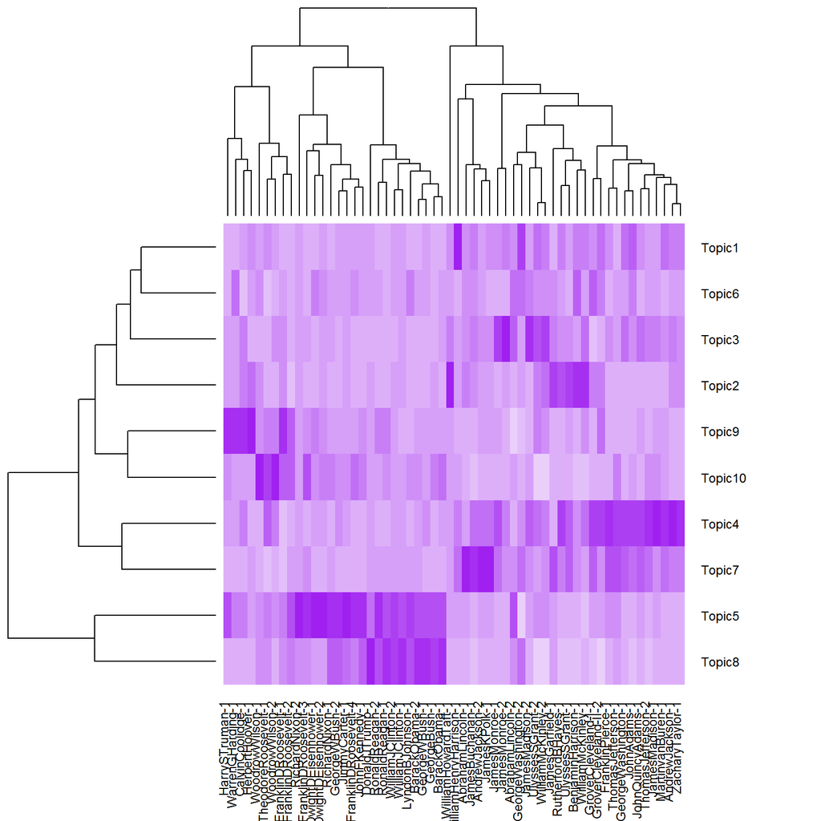

```r
heatmap.2(t(as.matrix(topic.summary[,topic.plot+1])),
          scale = "column", key=F,
         col=colorRampPalette(c("white","purple")),
          cexRow = 0.9, cexCol = 0.9, margins = c(8, 8),
          trace = "none", density.info = "none")
```

# Clustering of the presidents

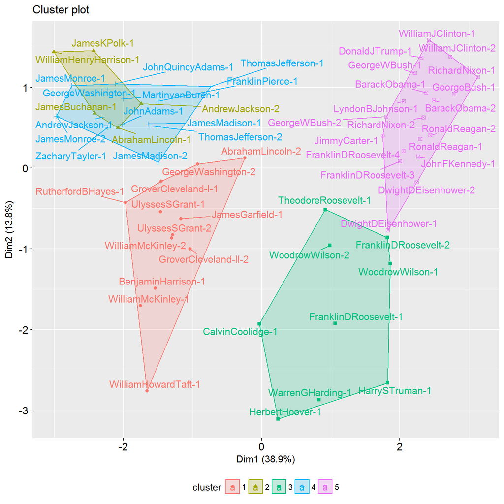

```r
presid.summary=tbl_df(docs.df)%>%
  #filter(type=="inaug", File%in%sel.comparison)%>%
  select(docs, Topic1:Topic10)%>%
  group_by(docs)%>%
  summarise_each(funs(mean))

presid.summary=as.data.frame(presid.summary)
rownames(presid.summary)=as.character(prez.out)
set.seed(19)

km.res=kmeans(scale(presid.summary[,-1]), iter.max=200,
              5)
fviz_cluster(km.res,
             stand=T, repel= TRUE,
             data = presid.summary[,-1],
             show.clust.cent=FALSE)
```

# Compute hierarchical clustering

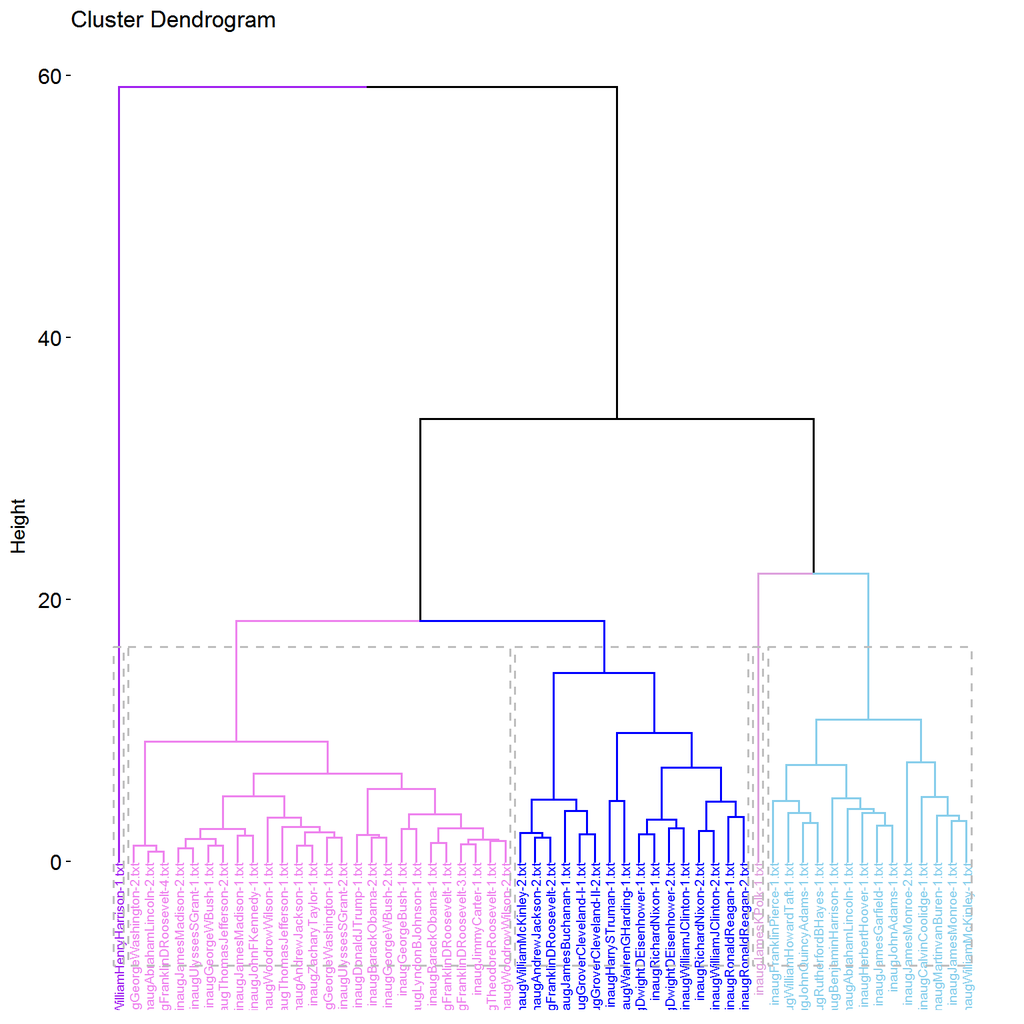

```r
set.seed(1999)
d <- dist(dtmss, method = "euclidean")
res <- hcut(d, k = 5, stand = TRUE)
fviz_dend(res, rect = TRUE, cex = 0.5,
          k_colors = c("purple","violet","blue","plum","skyblue"))
```

# Sentiment Analysis

```r
sentence.list=NULL
docs1<-Corpus(DirSource(folder.path,encoding = "UTF-8"))
docs1.df<-as.data.frame(docs1)

for(i in 1:nrow(docs1.df)){
  sentences=sent_detect(docs1.df$text[i],
                        endmarks = c("?", ".", "!", "|",";"))
  if(length(sentences)>0){
    emotions=get_nrc_sentiment(sentences)
    word.count=word_count(sentences)
    # colnames(emotions)=paste0("emo.", colnames(emotions))
    # in case the word counts are zeros?
    emotions=diag(1/(word.count+0.01)) %*% as.matrix(emotions)
    sentence.list=rbind(sentence.list,
                        cbind(docs1.df[i,-ncol(docs1.df)],
                              sentences=as.character(sentences),
                              word.count,
                              emotions,
                              sent.id=1:length(sentences)
                              )
    )
  }
}
```

Sentences with extreme emotions.

```r
speech.np=tbl_df(sentence.list)%>%
  select(sentences, negative:positive)
speech.np=as.data.frame(speech.np)

speech.df=tbl_df(sentence.list)%>%
  select(sentences, anger:trust)
speech.df=as.data.frame(speech.df)
as.character(speech.df$sentences[apply(speech.df[,-1], 2, which.max)])
```

```
## [1] "we've had dissension."
## [2] "God bless you."
## [3] "With riches has come inexcusable waste."
## [4] "government is the problem."
## [5] "Amen."
## [6] "Dark pictures and gloomy forebodings are worse than useless."
## [7] "They have been magnificent."
## [8] "Majority Leader."
```

# Conclusion:

From the analysis of the speeches, we can find that the words that the president used in their inaugspeech have a lot in commom, which make sense considering the situations they were facing at that time.However, there are also some differences in the words choice due to the time background and personality.